# Milestone Report

Raghav Pradhan

2025-02-20

# Overview

This is my Milestone report for my final data science project.

The project is concerned with showing my progress in the NLP(*New Language Processing*) project, from downloading the data to summarizing,exploring the data and also my future plans for training my Predictive model with this data.

## Loading the libraries

```r
require(tm)
require(ngram)
require(ggplot2)
require(stringi)
require(stringr)
require(dplyr)
require(wordcloud)
require(RColorBrewer)
```

## Downloading & loading the data

```r
trainURL <- "https://d396qusza40orc.cloudfront.net/dsscapstone/dataset/Coursera-SwiftKey.zip"
trainDataFile <- "data/Coursera-SwiftKey.zip"

#reading the data
con <- file("en_US.twitter.txt", "r") #making a connection with the file
twt <- readLines(con)  #reading the lines
close(con)  #closing the connection

con_blo <- file("en_US.blogs.txt","r")
blog <- readLines(con_blo)
close(con_blo)

con_new <- file("en_US.news.txt","r")
news <- readLines(con_new)
close(con_new)
```

we see that there are 3 text files that we will be using for further analysis & model training, but let us first summarise these text files:

- Twitter
- Blogs
- News

```r
size.file <- round(file.info(c("en_US.twitter.txt","en_US.news.txt","en_US.blogs.txt"))$size / 1024 ^ 2)  #size of files


word_twt <- stri_count_words(twt)
word_blog <- stri_count_words(blog)  #data into words
word_news <- stri_count_words(news)

## now summarising the Dataset into a simple data Frame

data <- data.frame(source = c("Twitter","News","Blog"),
                   size = paste(size.file,"MB"),
                   no_of_lines = c(length(word_twt),length(word_news),length(word_blog)),
                   no_of_words = c(sum(word_twt),sum(word_news),sum(word_blog)))
data
```

```
##    source   size no_of_lines no_of_words
## 1 Twitter 159 MB     2360148    30096649
## 2    News 196 MB     1010242    34762658
## 3    Blog 200 MB      899288    37546806
```

We see that even though twitter has high number of lines the number of words is very much similar compared to its counterparts, that is probably because a tweet is only limited to certain words.

The size of all these data are very large which can hinder our future analysis by long processing time & memory storage, so we will be trimming the data for smooth processing.

Now after summarizing the data let us proceed further.

## Sampling the data

```r
set.seed(200)
sample.data <- c(sample(twt,length(twt) * 0.01),sample(blog,length(blog) * 0.01),sample(news,length(news) * 0.01))
```

## Building a corpus

Corpus is a collection of a structured text which is very much important in NLP for analysing and processing text data.

I will be making a function that will turn the sampled text data into a corpus and also do all of these steps:

Firstly we need to get the bad words or profane data set that I will be using in the function to detect and remove from the corpus.

```r
url = "https://github.com/dsojevic/profanity-list/blob/main/en.txt" #downloaded the profanity words from this git repo
```

Now let us make the **bcorpus** function.

```r
bcorpus <- function(dataset) {
  data <- VCorpus(VectorSource(dataset))
  space <- content_transformer(function(x,pattern) gsub(pattern," ",x))  #a nested func to get rid of any pattern by repalcing it with empty space

  #getting rid of those particular patterns with space func

  data <- tm_map(data,space ,"\\b[A-Z a-z 0-9._ - ]*[@](.*?)[.]{1,3} \\b")        #EMAIL pattern
  data <- tm_map(data,space,"@[^\\s]+")                                           #twitter pattern
  data <- tm_map(data,space ,"(f|ht)tp(s?)://(.*)[.][a-z]+")                      #Url pattern

  #now getting rid of all the bad words

  bad_words <- file("en.txt","r")
  bad_words <- readLines(bad_words)
  data <- tm_map(data,removeWords,bad_words)

  #now getting rid of other things

  data <- tm_map(data,tolower)                                    # transforming the data into lower case
  data <- tm_map(data,removeNumbers)                              # removing the numbers
  data <- tm_map(data,removePunctuation)                          # removing punctuation marks
  data <- tm_map(data,stripWhitespace)                            # getting rid of extra white spaces
  data <- tm_map(data,PlainTextDocument)
  return(data)
}
```

Now using the bcorpus fucntion and saving it into a dataframe.

```r
data <- bcorpus(sample.data)  ## now using this function to turn it into corpus
saveRDS(data, file = "en_US.corpus.rds")  # saving the data in disk


# turning it into a data frame & saving it into disk
corpusText <- data.frame(text = unlist(sapply(data, '[', "content")), stringsAsFactors = FALSE)
con <- file("en_US.corpus.txt", open = "w")
writeLines(corpusText$text, con)
close(con)
```

## Exploratory Data analysis

Now we will be performing Exploratory Data Analysis to get the gist of the data so that we can further plan our model training approach which is very important.

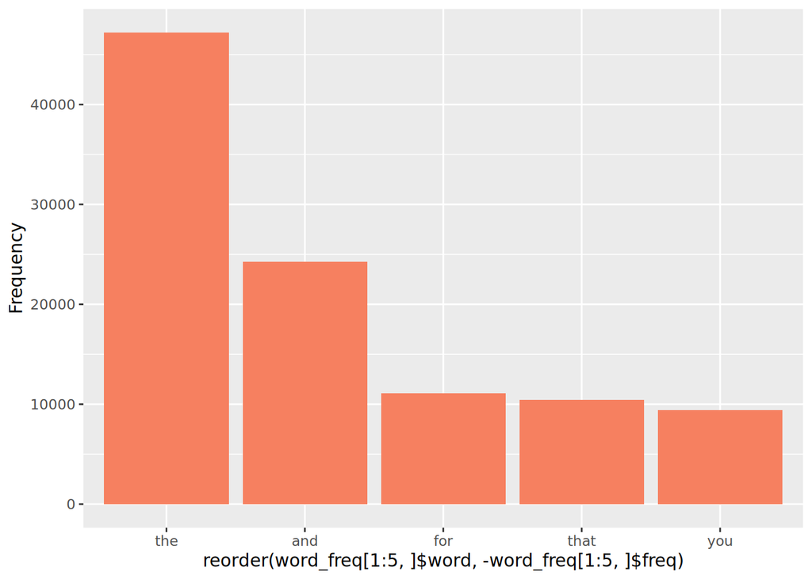

```r
tdm <- TermDocumentMatrix(data) #making it into a term document matrix which is a table with words and its frequency
frequency <- sort(rowSums(as.matrix(removeSparseTerms(tdm,0.99))),decreasing = TRUE) #converting it into matrix and using rowSums to get the freq of each word in descending order
word_freq <- data.frame(word = names(frequency),freq = frequency) #data frame with 2 cols, name and the frequency of the word

## plot for the top 5 most frequent words
ggplot(word_freq[1:5,], aes(x = reorder(word_freq[1:5,]$word, -word_freq[1:5,]$freq), y = word_freq[1:5,]$freq)) +
  geom_bar(stat = "identity",fill = "#f68060") + ylab("Frequency")
```

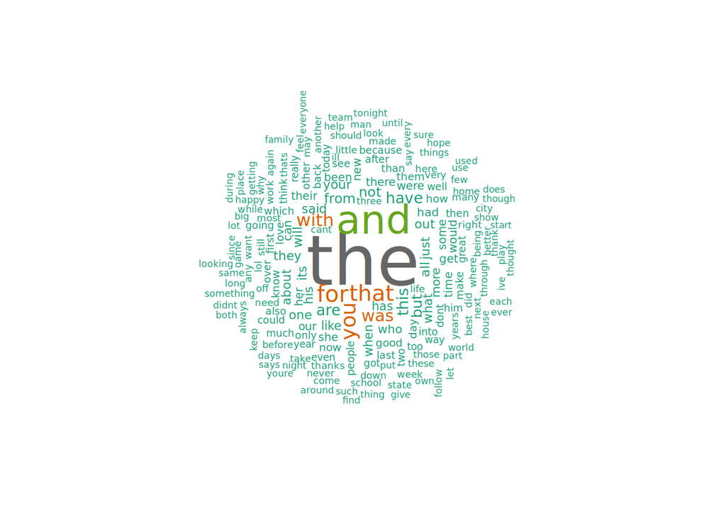

```r
## making a word cloud for the most appearing words
wordcloud(words = word_freq$word, freq = word_freq$freq, min.freq = 1,
          max.words=200, random.order=FALSE, rot.per=0.35,
          colors=brewer.pal(8, "Dark2"))
```

**I wanted to get rid of the stop words but since our corpus data was too small it was hard for my model to predict words for input that had alot of stopwords,because of that i have changed my approach**

## N-grams & tokenizing

For the N-gram generation, I wanted to use the *RWefa* package but since one of its dependencies is *rjava* which is somehow not compatible with my system ,so I will be going with *tm* & *ngram* package which i have been using already.

Firstly converting the corpus to a character vector as the ngram function only takes character string as input.

```r
text <- sapply(data, as.character)
```

### Uni-Gram

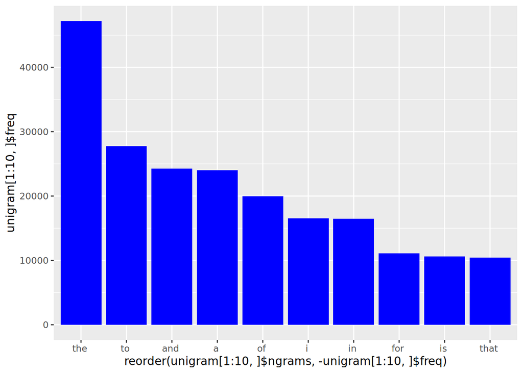

```r
unigram_result <- ngram(paste(text, collapse = " "), n = 1)  # For generating unigrams from the data

unigram_table <- get.phrasetable(unigram_result)  #getting a table of the unigrams along with the freq of the data

unigram <- as.data.frame(unigram_table) #into a df for visualization

ggplot(unigram[1:10,], aes(x = reorder(unigram[1:10,]$ngrams, - unigram[1:10,]$freq), y = unigram[1:10,]$freq)) +
  geom_bar(stat = "identity",fill = "blue")
```

```r
save(unigram,file = "unigram.RData")
```

### Bi-Gram

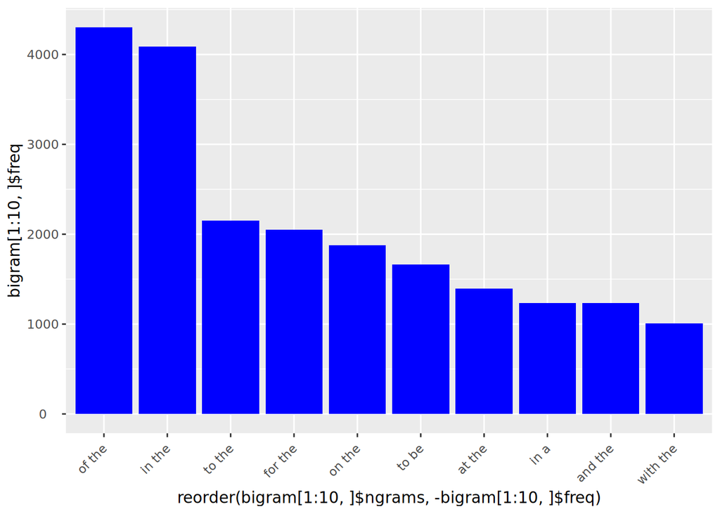

```r
bigram_result <- ngram(paste(text,collapse = " "), n = 2)

bigram_table <- get.phrasetable(bigram_result)

bigram <- as.data.frame(bigram_table)

ggplot(bigram[1:10,], aes(x = reorder(bigram[1:10,]$ngrams, - bigram[1:10,]$freq), y = bigram[1:10,]$freq)) +
  geom_bar(stat = "identity",fill = "blue") +  theme(axis.text.x = element_text(hjust = 1.0, angle = 45),
               axis.text.y = element_text(hjust = 0.5, vjust = 0.5))
```

```r
save(bigram,file = "bigram.RData")
```

### Tri-Gram

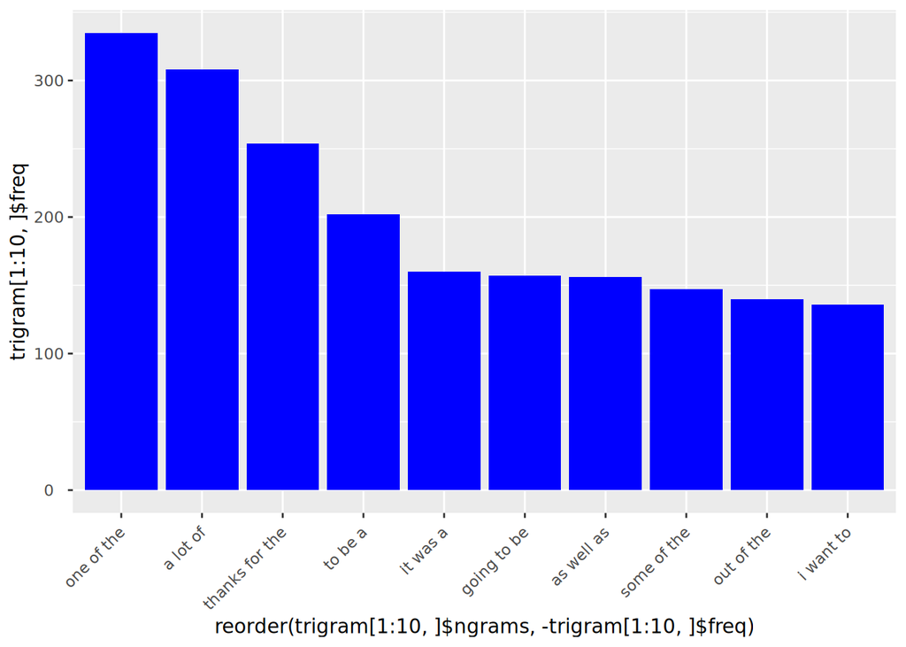

```r
trigram_result <- ngram(paste(text,collapse = " "),n = 3)

trigram_table <- get.phrasetable(trigram_result)

trigram <- as.data.frame(trigram_table)

ggplot(trigram[1:10,], aes(x = reorder(trigram[1:10,]$ngrams, - trigram[1:10,]$freq), y = trigram[1:10,]$freq)) +
  geom_bar(stat = "identity",fill = "blue") + theme(axis.text.x = element_text(hjust = 1.0, angle = 45),
               axis.text.y = element_text(hjust = 0.5, vjust = 0.5))
```

```r
save(trigram,file = "trigram.RData")
```

### Quad_gram

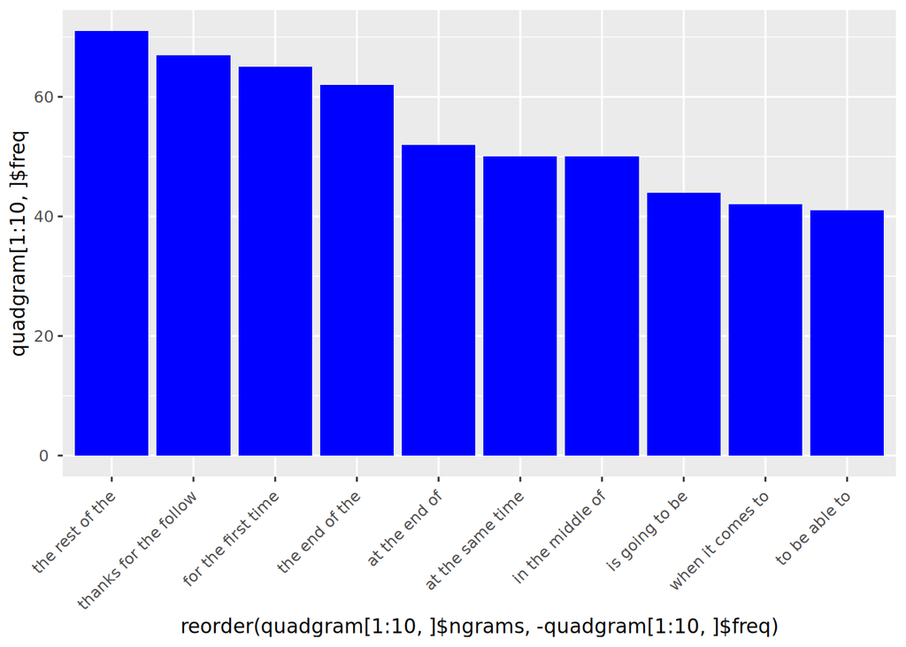

```r
quadgram_result <- ngram(paste(text,collapse = " "),n = 4)

quadgram_table <- get.phrasetable(quadgram_result)

quadgram <- as.data.frame(quadgram_table)

ggplot(quadgram[1:10,], aes(x = reorder(quadgram[1:10,]$ngrams, - quadgram[1:10,]$freq), y = quadgram[1:10,]$freq)) +
  geom_bar(stat = "identity",fill = "blue") + theme(axis.text.x = element_text(hjust = 1.0, angle = 45),
                                                    axis.text.y = element_text(hjust = 0.5, vjust = 0.5))
```

```r
save(quadgram,file = "quadgram.RData")
```